# Group work: Refining existing plot

Fabian Gülzau

9 Dezember 2017

### Refining existing plots

In the next session, we will try to improve existing plots. In order to facilitate this task, I ask you to look for existing figures that you find lacking in regard to visual presentation. Please, bring them to our next session. In addition, you should create a data frame with the information needed to reproduce the figure. Below, you find an example from the “Frankfurter Allgemeine Zeitung” (FAZ).

### The existing plot

FAZ, August 10 2017: “Abstiegsangst weicht dem Aufstiegsglück” [(whole article)](http://plus.faz.net/wirtschaft/2017-08-10/2515d454fb336e9e150acf1cac2b6640/?GEPC=s2)

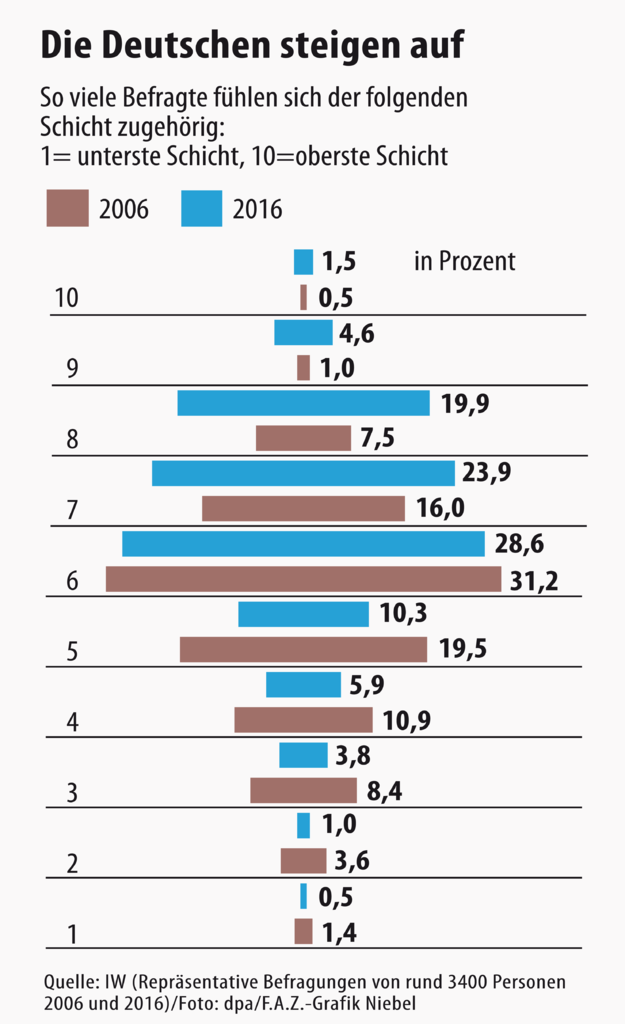

### Identifying parts of the plot

Basically, the plot only includes one variable measuring the subjectively perceived societal rank (or class). This one is measured on a scale ranging from 1-10. Here, it is given as percentages already. In addition, we have two points in time (2006 and 2016).

Now, we can create a data frame holding all the necessary data. We will be using a `tibble` which is a `data.frame` with some additional functionality (see: [Wickham & Grolemund 2017, Ch. 10 (optional)](http://r4ds.had.co.nz/tibbles.html)).

### Creating a data frame

First, we need to load the necessary packages:

```r
library(tidyverse)
```

Then, we can start creating our data frame. I’ll create a vector for each column in order to combine them afterwards. In addition, I’ll use tidy data which is known as long format in the social sciences. Again, there is a chapter in [Wickham & Grolemund (2017), Ch. 12 (optional)](http://r4ds.had.co.nz/tidy-data.html).

Here, we also use factors a data type that we didn’t discuss yet. However, it is just a representation of labelled ordered or nominal variables (a recommended reading is: [Wickham & Grolemund 2017, Ch. 15 (recommended)](http://r4ds.had.co.nz/factors.html))

```r
year <- factor(c(rep(2006, times = 10), rep(2016, times = 10)),
               levels = c(2006,2016))
values <- c(1.4, 3.6, 8.4, 10.9, 19.5, 31.2, 16.0, 7.5, 0.5, 1.0, # 2006
            0.5, 1.0, 3.8, 5.9, 10.3, 28.6, 23.9, 19.9, 4.6, 1.5) # 2016
class <- factor(c(rep(1:10, times = 2)),
                levels = 1:10)

# Combine:
faz.data <- tibble(
  year = year,
  values = values,
  class = class)

# Have a look
glimpse(faz.data)
```

```
## Observations: 20
## Variables: 3
## $ year   <fctr> 2006, 2006, 2006, 2006, 2006, 2006, 2006, 2006, 2006, ...
## $ values <dbl> 1.4, 3.6, 8.4, 10.9, 19.5, 31.2, 16.0, 7.5, 0.5, 1.0, 0...
## $ class  <fctr> 1, 2, 3, 4, 5, 6, 7, 8, 9, 10, 1, 2, 3, 4, 5, 6, 7, 8,...
```

Now, a rough reproduction of the plot. That’s a task, we will do in the session.

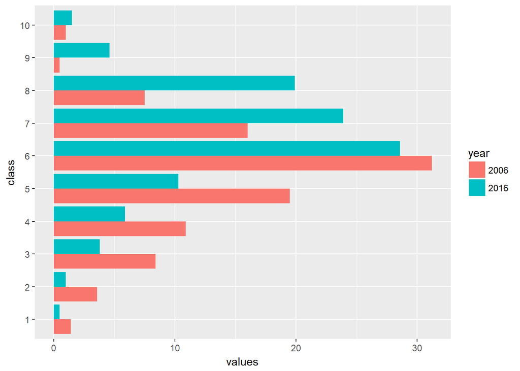

```r
ggplot(data = faz.data, mapping = aes(x = class, y = values, fill = year)) +
  geom_bar(stat = "identity", position = "dodge") +
  coord_flip()
```

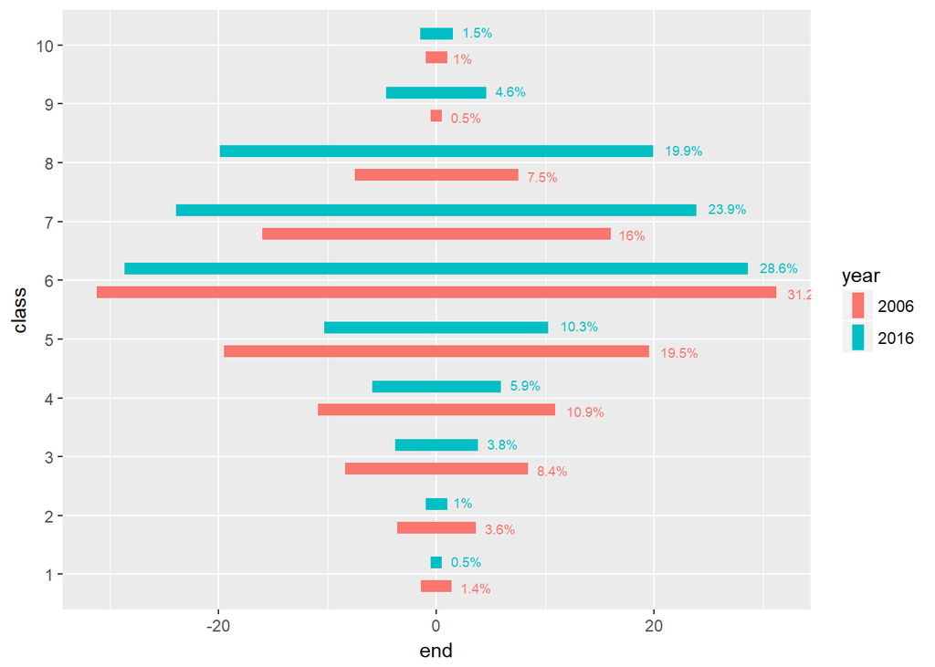

```r
faz.data.re <- faz.data %>%
  mutate(start = -values,
         end = values)

ggplot(data = faz.data.re, mapping = aes(x = class, color = year)) +
  geom_linerange(mapping = aes(ymin = start, ymax = end),
                 size = 3,
                 position = position_dodge(width = 0.80)) +
  geom_text(mapping = aes(y = end, label = paste0(values, "%")),
            size = 2.5,
            position = position_dodge(width = 0.9),
            hjust = -0.3) +
  coord_flip()
```